# NIAID-1418 Spectral Signature Analysis

5-Laser vs 6-Laser Configuration and Fixation Effects

## 0.1 Project Goals

*The project goals below are copied exactly from the RTB Flow Core Slide Deck.*

- **Main goal:** Impact of number of lasers (5L x 6L) and fixation in panel resolution in the spectral signature of fluorochromes
- **Specific aims:**
  1. **Instrument configuration:**
     - 1. Peak shift?
     - 2. Is similarity between fluors constant?
  2. **Fixation impact:**
     - 1. Overall impact of each treatment – any worse?
     - 2. Type of fluor more susceptible?
     - 3. Impact of number of lasers

# 1 Q1 — Instrument configuration

## 1.1 Q1a — Do spectral peaks shift?

**Answer to Q1a:**

**Yes, spectral peaks can shift, but treatment-associated peak shifts were uncommon.** Most fluorochrome × treatment comparisons remained **Stable** (77.9% for 1% PFA, 73.8% for 4% PFA, and 74.5% for Perm). Configuration-only peak differences accounted for approximately 12–13% of cases and were almost entirely associated with the dUV block. Treatment-associated peak changes affecting both 5L and 6L occurred in 6.9–10.3% of cases, while configuration-specific treatment effects were rare (≤3.4%). Near-tied maxima should be interpreted cautiously because small differences between nearly equal detector values can change which detector is identified as the maximum.

The results below separate configuration-only peak differences from treatment-associated peak changes and stable spectra. **Definitions and criteria for each reporting category are provided in the Appendix.**

Q1a — peak-behavior categories by treatment

| Treatment | Reporting category | N | Percent (%) |
| --- | --- | --- | --- |
| 1% PFA | Configuration Only – dUV Block Difference | 18 | 12.4 |
| 1% PFA | Configuration Only – Comparable Area | 0 | 0.0 |
| 1% PFA | Treatment Effect – 5L Only | 3 | 2.1 |
| 1% PFA | Treatment Effect – 6L Only | 1 | 0.7 |
| 1% PFA | Treatment Effect – Both Configurations | 10 | 6.9 |
| 1% PFA | Stable | 113 | 77.9 |
| 4% PFA | Configuration Only – dUV Block Difference | 18 | 12.4 |
| 4% PFA | Configuration Only – Comparable Area | 0 | 0.0 |
| 4% PFA | Treatment Effect – 5L Only | 5 | 3.4 |
| 4% PFA | Treatment Effect – 6L Only | 0 | 0.0 |
| 4% PFA | Treatment Effect – Both Configurations | 15 | 10.3 |
| 4% PFA | Stable | 107 | 73.8 |
| Perm | Configuration Only – dUV Block Difference | 19 | 13.1 |
| Perm | Configuration Only – Comparable Area | 0 | 0.0 |
| Perm | Treatment Effect – 5L Only | 3 | 2.1 |
| Perm | Treatment Effect – 6L Only | 1 | 0.7 |
| Perm | Treatment Effect – Both Configurations | 14 | 9.7 |
| Perm | Stable | 108 | 74.5 |

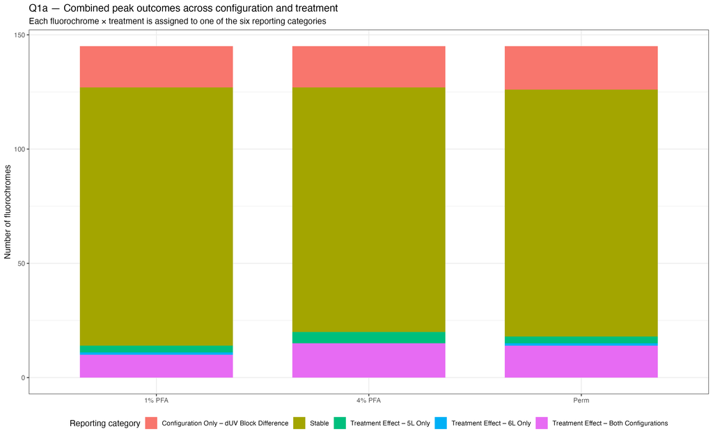

Links to the corresponding plots are provided in the last column of the table for each relevant fluorochrome row.

| Fluorochrome | Treatment | Reporting_category | 5L Unfixed peak | 5L Treated peak | 6L Unfixed peak | 6L Treated peak | Unfixed 5L vs 6L difference | Unfixed comparison area | Treated 5L vs 6L difference | Treated comparison area | Treatment change 5L | Treatment change 6L | Near tie | Peak call confidence | Plot_relative_path |
| --- | --- | --- | --- | --- | --- | --- | --- | --- | --- | --- | --- | --- | --- | --- | --- |
| af350 | 1% PFA | Configuration Only – dUV Block Difference | 355-432 | 355-432 | 320-432 | 320-432 | True | 320-nm dUV area absent from 5L | True | 320-nm dUV area absent from 5L | False | False | False | Firm - clear single maximum | View plot |
| buv395 | 1% PFA | Configuration Only – dUV Block Difference | 355-375 | 355-375 | 320-375 | 320-375 | True | 320-nm dUV area absent from 5L | True | 320-nm dUV area absent from 5L | False | False | False | Firm - clear single maximum | View plot |
| buv496 | 1% PFA | Configuration Only – dUV Block Difference | 355-511 | 355-511 | 320-511 | 320-511 | True | 320-nm dUV area absent from 5L | True | 320-nm dUV area absent from 5L | False | False | False | Firm - clear single maximum | View plot |
| buv737 | 1% PFA | Configuration Only – dUV Block Difference | 355-738 | 355-738 | 320-738 | 320-738 | True | 320-nm dUV area absent from 5L | True | 320-nm dUV area absent from 5L | False | False | False | Firm - clear single maximum | View plot |
| dl350 | 1% PFA | Configuration Only – dUV Block Difference | 355-432 | 355-432 | 320-432 | 320-432 | True | 320-nm dUV area absent from 5L | True | 320-nm dUV area absent from 5L | False | False | False | Firm - clear single maximum | View plot |
| iflour350 | 1% PFA | Configuration Only – dUV Block Difference | 405-449 | 405-449 | 320-432 | 320-432 | True | 320-nm dUV area absent from 5L | True | 320-nm dUV area absent from 5L | False | False | False | Firm - clear single maximum | View plot |
| live or dye 330/410 | 1% PFA | Configuration Only – dUV Block Difference | 355-375 | 355-375 | 320-375 | 320-375 | True | 320-nm dUV area absent from 5L | True | 320-nm dUV area absent from 5L | False | False | False | Firm - clear single maximum | View plot |
| livedeadfixableblue | 1% PFA | Configuration Only – dUV Block Difference | 355-432 | 355-432 | 320-432 | 320-432 | True | 320-nm dUV area absent from 5L | True | 320-nm dUV area absent from 5L | False | False | False | Firm - clear single maximum | View plot |
| sparkuv-387 | 1% PFA | Configuration Only – dUV Block Difference | 355-375 | 355-375 | 320-375 | 320-375 | True | 320-nm dUV area absent from 5L | True | 320-nm dUV area absent from 5L | False | False | False | Firm - clear single maximum | View plot |
| starbright uv 445 | 1% PFA | Configuration Only – dUV Block Difference | 355-432 | 355-432 | 320-432 | 320-432 | True | 320-nm dUV area absent from 5L | True | 320-nm dUV area absent from 5L | False | False | False | Firm - clear single maximum | View plot |

[output cut: 425 more lines]

## 1.2 Q1b — Is similarity between fluorochromes constant?

**Answer to Q1b:**

**Across unfixed, 1% PFA, 4% PFA, and Perm conditions, fluorochrome similarity was generally stable between 5L and 6L, but it was not identical.** Cosine similarity measures how similar the spectral shapes of two fluorochromes are, where values closer to 1 indicate more similar spectra. For each condition, pairwise cosine similarity was compared directly between the 5L and 6L configurations.

Across conditions, the median absolute difference in pairwise cosine similarity between 5L and 6L was only **0.0008–0.0013**. This means that, for a typical fluorochrome pair, changing from 5L to 6L produced almost no change in how similar their spectra were. The number of highly similar fluorochrome pairs (cosine similarity ≥ 0.90) was also nearly the same between configurations.

However, a small number of fluorochrome pairs behaved differently. Among the fixation/permeabilization treatments, the **largest differences ranged from 0.197 to 0.415** (Perm = 0.197, 4% PFA = 0.335, and 1% PFA = 0.415). These values were much larger than the typical difference of 0.0008–0.0013. **In simple terms, 5L and 6L produce very similar fluorochrome-to-fluorochrome relationships overall, but a few specific fluorochrome pairs can show much larger differences between the two configurations.**

**Cosine similarity** is the primary measure. Cosine similarity was used to quantify the similarity between fluorochrome spectral signatures across detectors. In spectral flow cytometry, cosine similarity provides a pairwise measure of spectral overlap, with values approaching 1 indicating increasingly similar spectral shapes. This metric is commonly used for evaluating fluorochrome similarity, panel design, and spectral stability (Jensen et al., 2021; Rajwa et al., 2025; Mage et al., 2026). Values approaching 1 indicate increasingly similar spectral shapes. The clustered heatmaps show broader spectral neighborhoods; the pairwise table gives the exact 5L and 6L cosine similarity for each pair of different fluorochromes.

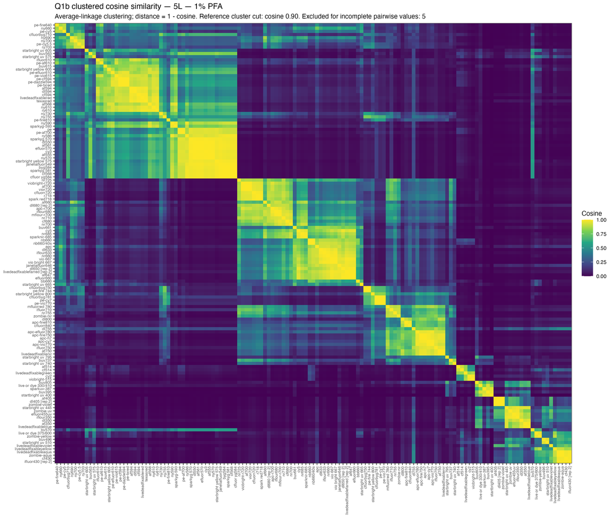

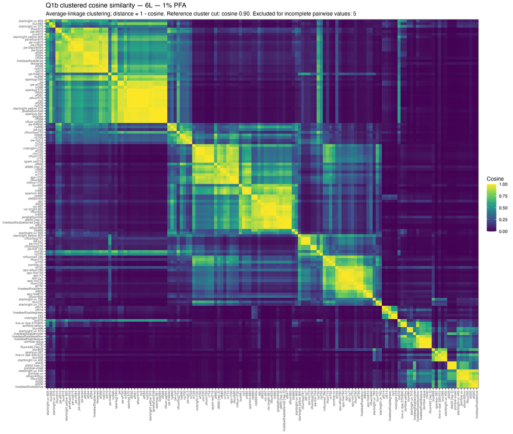

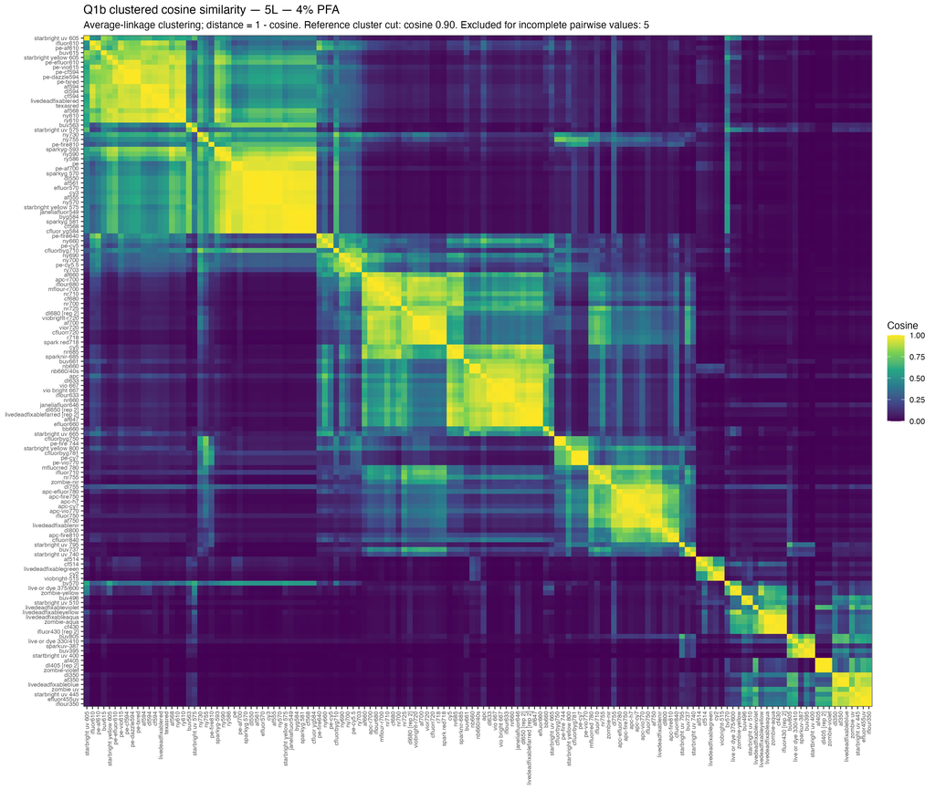

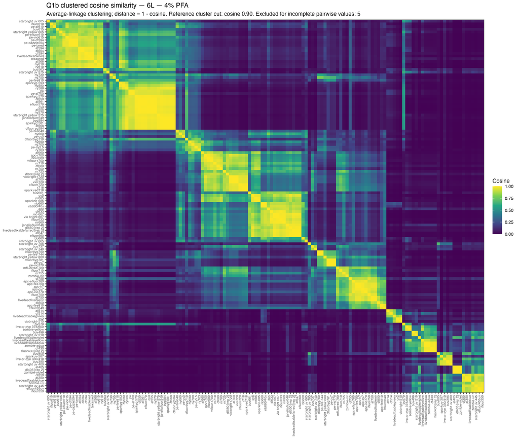

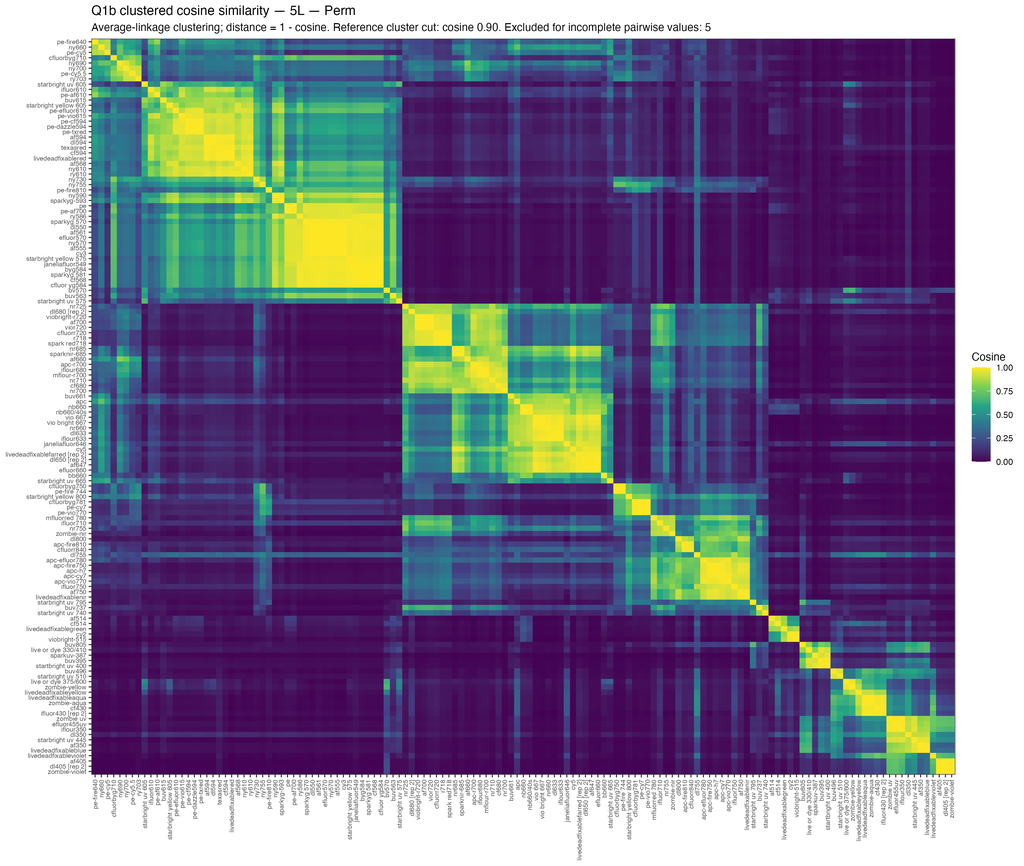

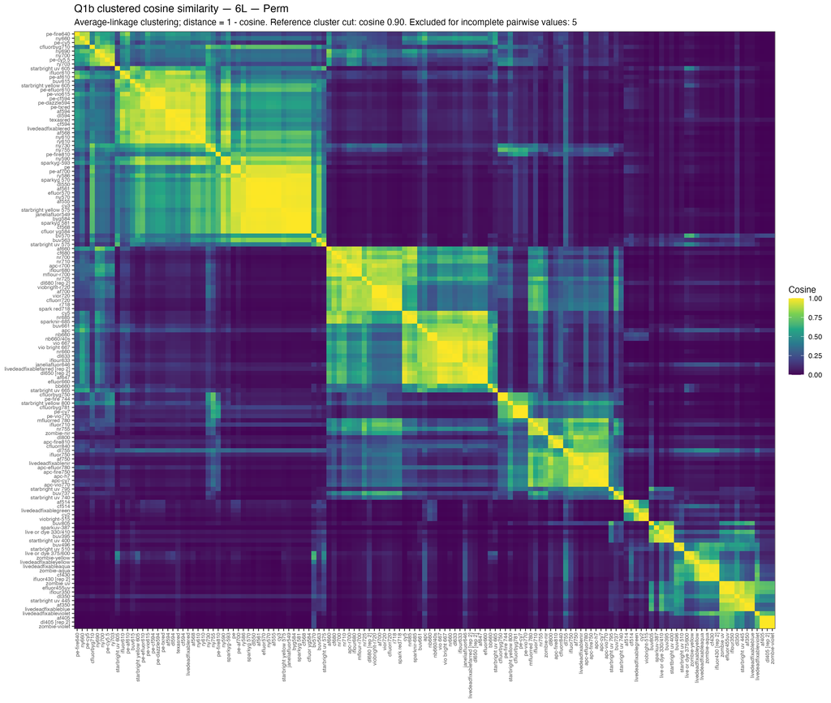

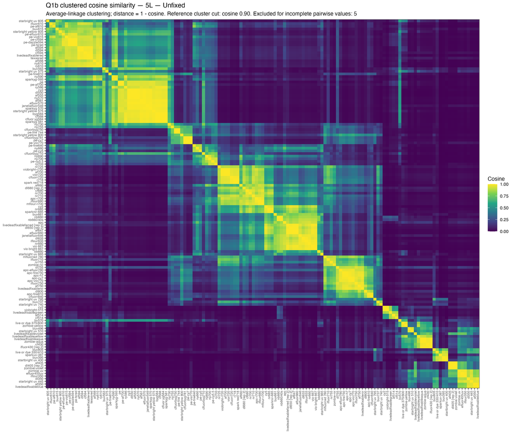

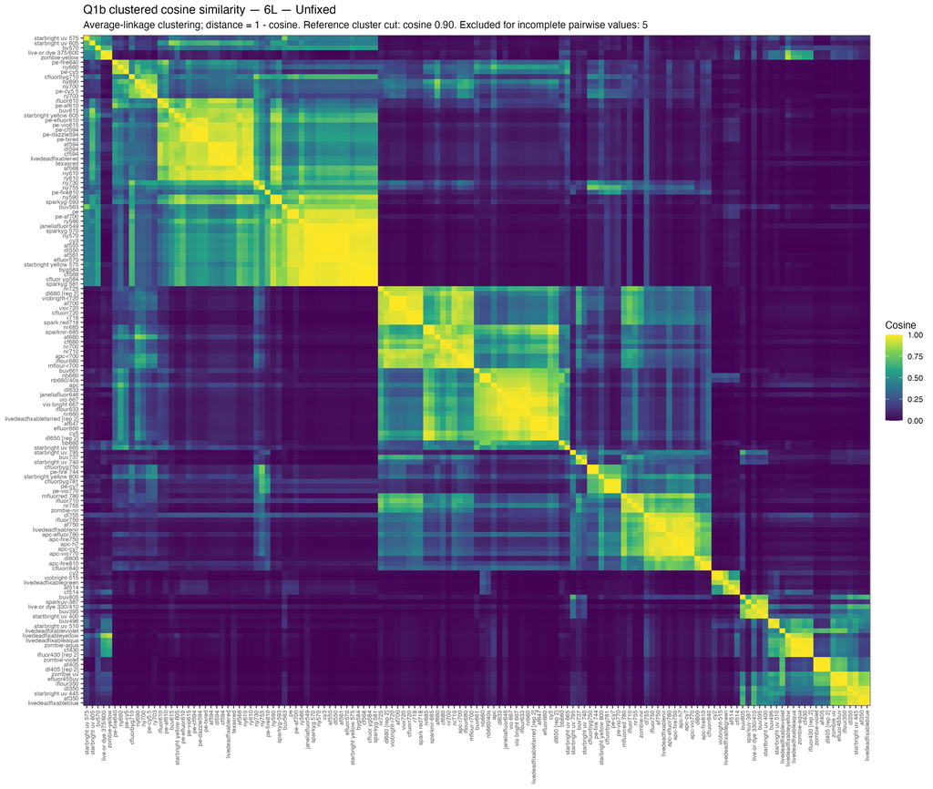

| Treatment | Fluor_A | Fluor_B | Cosine_5L | Cosine_6L | Delta_cosine_5L_minus_6L | Abs_delta_cosine | >=0.90 in 5L | >=0.90 in 6L | >=0.90 in both | >=0.90 in either | Highest_cosine |
| --- | --- | --- | --- | --- | --- | --- | --- | --- | --- | --- | --- |
| 1% PFA | efluor570 | af561 | 0.9999559850774422 | 0.999974733317964 | -1.874824052183754e-05 | 1.874824052183754e-05 | True | True | True | True | 0.999974733317964 |
| 1% PFA | cf568 | cfluor yg584 | 0.9999681615695436 | 0.9999727002591352 | -4.538689591604417e-06 | 4.538689591604417e-06 | True | True | True | True | 0.9999727002591352 |
| 1% PFA | sparkyg 581 | cfluor yg584 | 0.9999661282643544 | 0.9999413199616266 | 2.480830272766354e-05 | 2.480830272766354e-05 | True | True | True | True | 0.9999661282643544 |
| 1% PFA | cf568 | byg584 | 0.9999579122483688 | 0.9999453809945952 | 1.253125377376207e-05 | 1.253125377376207e-05 | True | True | True | True | 0.9999579122483688 |
| 1% PFA | sparkyg 581 | cf568 | 0.9999064380671698 | 0.9998593989350782 | 4.703913209158639e-05 | 4.703913209158639e-05 | True | True | True | True | 0.9999064380671698 |
| 1% PFA | cfluor yg584 | byg584 | 0.999892298454032 | 0.99987442558363 | 1.787287040211361e-05 | 1.787287040211361e-05 | True | True | True | True | 0.999892298454032 |
| 1% PFA | dl405 [rep 2] | zombie-violet | 0.9998624078535542 | 0.9998388928453592 | 2.351500819508523e-05 | 2.351500819508523e-05 | True | True | True | True | 0.9998624078535542 |
| 1% PFA | efluor570 | dl550 | 0.9998457195686924 | 0.9998072407916344 | 3.847877705787095e-05 | 3.847877705787095e-05 | True | True | True | True | 0.9998457195686924 |
| 1% PFA | cfluorbyg750 | pe-fire 744 | 0.9998281012466892 | 0.999829659036944 | -1.557790254680391e-06 | 1.557790254680391e-06 | True | True | True | True | 0.999829659036944 |
| 1% PFA | sparkyg 581 | byg584 | 0.9998117798519418 | 0.9997193656619204 | 9.241419002137265e-05 | 9.241419002137265e-05 | True | True | True | True | 0.9998117798519418 |

[output cut: 41154 more lines]

# 2 Q2 — Fixation impact

## 2.1 Q2a — What is the overall impact of each treatment?

**Answer to Q2a:**

**Perm had the greatest overall impact on spectral signatures, 4% PFA was intermediate, and 1% PFA had the smallest impact.** Median RMSE followed the same ordering in both configurations: **Perm > 4% PFA > 1% PFA** (5L: 0.0074 > 0.0062 > 0.0053; 6L: 0.0078 > 0.0061 > 0.0053). Because higher RMSE indicates greater deviation from the corresponding Unfixed spectrum, Perm produced the largest spectral change and 1% PFA the smallest. Treatment differences were statistically significant in both 5L and 6L (Friedman P < 0.001), although the overall effect sizes were modest (Kendall W = 0.126 and 0.096, respectively). All pairwise treatment comparisons remained significant after BH correction, with the largest separation occurring between 1% PFA and Perm in both configurations.

Each treated spectrum is compared with the **corresponding Unfixed spectrum in the same configuration**. RMSE is the primary magnitude measure: higher RMSE means a larger treatment-associated spectral change.

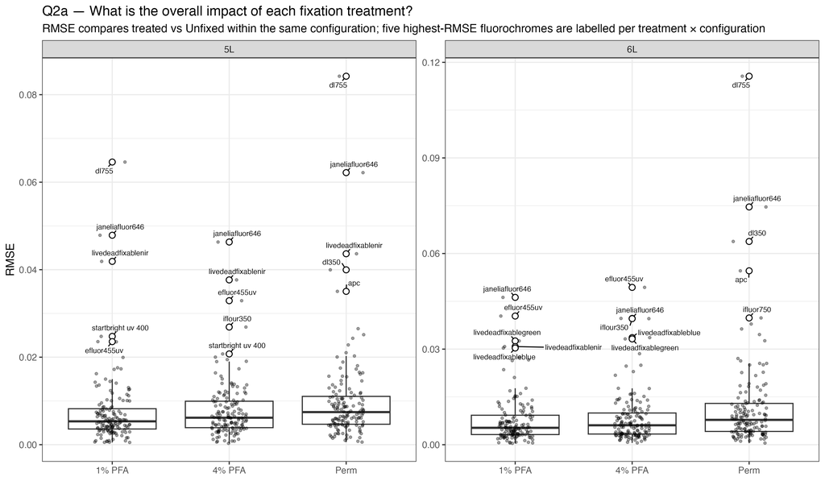

Q2a — overall treatment comparison

| Config | Test | N_fluorochromes | Statistic | df | P value | Kendall W |
| --- | --- | --- | --- | --- | --- | --- |
| 5 | Friedman (RMSE blocked by fluorochrome) | 144 | 36.264 | 2 | < 0.001 | 0.126 |
| 6 | Friedman (RMSE blocked by fluorochrome) | 144 | 27.597 | 2 | < 0.001 | 0.096 |

| Config | Treatment_A | Treatment_B | N_pairs | Median_RMSE_A | Median_RMSE_B | Median_paired_difference | Rank-biserial r | P | P (BH) | Direction |
| --- | --- | --- | --- | --- | --- | --- | --- | --- | --- | --- |
| 5 | 1% PFA | Perm | 144 | 0.0053 | 0.0074 | -0.0013 | -0.5571 | &lt; 0.001 | &lt; 0.001 | Perm larger spectral change |
| 5 | 1% PFA | 4% PFA | 144 | 0.0053 | 0.0062 | -0.0003 | -0.3588 | &lt; 0.001 | &lt; 0.001 | 4% PFA larger spectral change |
| 5 | 4% PFA | Perm | 144 | 0.0062 | 0.0074 | -0.0004 | -0.2452 | 0.011 | 0.011 | Perm larger spectral change |
| 6 | 1% PFA | Perm | 144 | 0.0053 | 0.0078 | -0.0009 | -0.5255 | &lt; 0.001 | &lt; 0.001 | Perm larger spectral change |
| 6 | 4% PFA | Perm | 144 | 0.0061 | 0.0078 | -0.0005 | -0.3563 | &lt; 0.001 | &lt; 0.001 | Perm larger spectral change |
| 6 | 1% PFA | 4% PFA | 144 | 0.0053 | 0.0061 | -0.0003 | -0.3071 | 0.001 | 0.001 | 4% PFA larger spectral change |

## 2.2 Q2b — Are particular fluorochromes or fluorochrome types more susceptible?

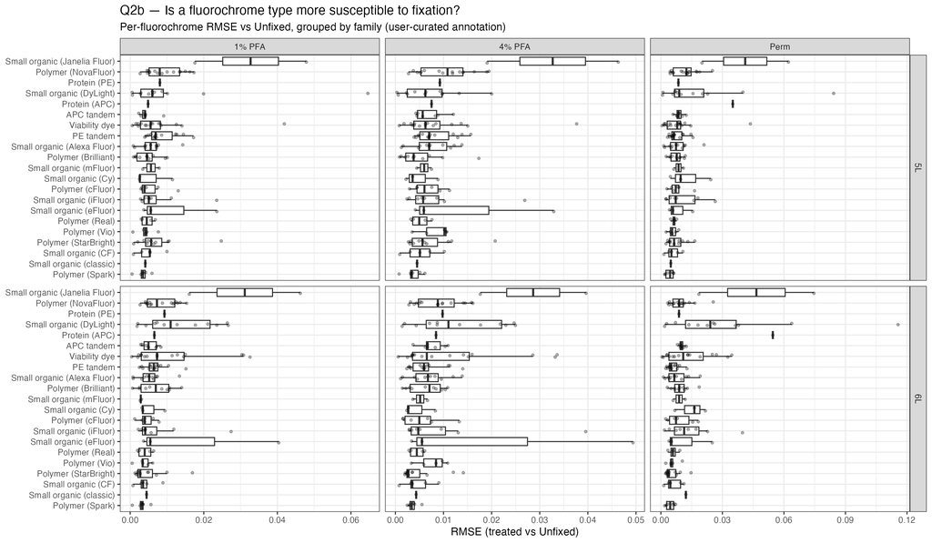

Q2b — fluorochrome-family susceptibility test

| Config | Treatment | N_families | N_fluorochromes | Chi-squared | df | P | P (BH) | Epsilon squared |
| --- | --- | --- | --- | --- | --- | --- | --- | --- |
| 5 | 1% PFA | 16 | 126 | 18.846 | 15 | 0.221 | 0.356 | 0.151 |
| 5 | 4% PFA | 16 | 126 | 17.448 | 15 | 0.293 | 0.356 | 0.140 |
| 5 | Perm | 16 | 126 | 16.405 | 15 | 0.356 | 0.356 | 0.131 |
| 6 | 1% PFA | 16 | 126 | 18.330 | 15 | 0.246 | 0.356 | 0.147 |
| 6 | 4% PFA | 16 | 126 | 17.339 | 15 | 0.299 | 0.356 | 0.139 |
| 6 | Perm | 16 | 126 | 27.008 | 15 | 0.029 | 0.172 | 0.216 |

| Config | Fluor_ID | Mean_RMSE | Median_RMSE | Mean_Pearson | Mean_Cosine | Mean_max_abs_detector_difference | Mean_abs_intensity_change_percent | Mean_abs_peak_shift_nm | Rank_RMSE | Rank_Pearson_disruption | Rank_Cosine_disruption | Rank_Max_difference | Rank_Intensity_change | Rank_Peak_shift |
| --- | --- | --- | --- | --- | --- | --- | --- | --- | --- | --- | --- | --- | --- | --- |
| 5 | af350 | 0.00924288749985723 | 0.01129063455168071 | 0.9972934273209264 | 0.9971929746904804 | 0.05004141666666668 |  | 0 | 41 | 26 | 20 | 51 | 1 | 24 |
| 5 | af405 | 0.00128071829082497 | 0.00140585370408183 | 0.9999452400090104 | 0.9999458052955332 | 0.01132570000000002 |  | 0 | 139 | 139 | 138 | 137 | 2 | 24 |
| 5 | af514 | 0.00462665648055124 | 0.00480666813250433 | 0.9995938549993536 | 0.9996135251335864 | 0.02754933333333333 |  | 8 | 105 | 102 | 103 | 104 | 3 | 15 |
| 5 | af555 | 0.01637550044904723 | 0.01428407860384582 | 0.9963808617835171 | 0.996534424847698 | 0.1428303666666668 |  | 4 | 11 | 16 | 17 | 8 | 4 | 19 |
| 5 | af561 | 0.00141510453115307 | 0.00123549814205676 | 0.9999434177365052 | 0.9999463070370198 | 0.0075974933333333 |  | 0 | 138 | 138 | 139 | 140 | 5 | 24 |
| 5 | af568 | 0.00769228029094689 | 0.00768172654555726 | 0.9990572471307336 | 0.9991023642860952 | 0.07444730000000017 |  | 0 | 58 | 61 | 57 | 27 | 6 | 24 |
| 5 | af594 | 0.00653154941487804 | 0.00702263661968582 | 0.998832238521374 | 0.9988590806097972 | 0.03120033333333334 |  | 0 | 69 | 47 | 43 | 88 | 7 | 24 |
| 5 | af647 | 0.00450156892975068 | 0.00437145980493782 | 0.9995089318036848 | 0.999546881161906 | 0.03398716666666671 |  | 0 | 106 | 94 | 94 | 78 | 8 | 24 |
| 5 | af660 | 0.00968933675408953 | 0.01045682436784399 | 0.9989915033655596 | 0.9991393166651928 | 0.05520150000000001 |  | 0 | 40 | 55 | 59 | 47 | 9 | 24 |
| 5 | af700 | 0.00760581453675558 | 0.00738793278797358 | 0.9990587233930588 | 0.9991957779071744 | 0.05129306666666663 |  | 0 | 60 | 62 | 64 | 49 | 10 | 24 |

[output cut: 278 more lines]

## 2.3 Q2c — Does the impact of fixation differ between 5L and 6L?

**Answer to Q2c:**

**Overall, the magnitude of fixation-associated spectral change was similar between 5L and 6L, but individual fluorochromes showed configuration-dependent differences.** Treatment-level median RMSE values were very close between configurations (1% PFA: 0.0053 in both; 4% PFA: 0.0062 in 5L vs. 0.0061 in 6L; Perm: 0.0074 in 5L vs. 0.0078 in 6L). The median absolute paired 5L–6L RMSE difference was small—approximately 0.0011 for 1% PFA, 0.0011 for 4% PFA, and 0.0015 for Perm—although some individual fluorochrome × treatment pairs deviated more strongly from the 1:1 relationship. Thus, configuration does not produce a large uniform shift in fixation impact, but it can affect the measured response of specific fluorochromes.

For the same fluorochrome and treatment, fixation RMSE in 5L is compared directly with fixation RMSE in 6L. The 1:1 line represents equal measured fixation effect in the two configurations.

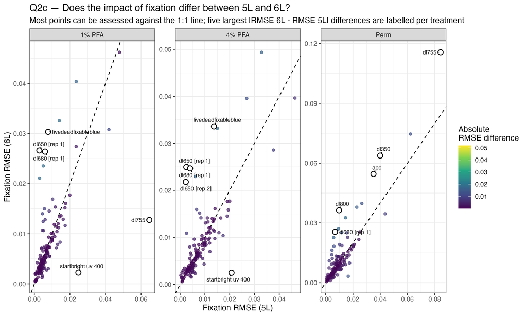

| Treatment | Fluor_ID | RMSE_5L | RMSE_6L | Pearson_5L | Pearson_6L | Cosine_5L | Cosine_6L | Max_abs_detector_difference_5L | Max_abs_detector_difference_6L | Total_intensity_change_percent_5L | Total_intensity_change_percent_6L | Peak_shift_nm_5L | Peak_shift_nm_6L | Abs_peak_shift_nm_5L | Abs_peak_shift_nm_6L | Delta_RMSE_6L_minus_5L | Delta_Pearson_6L_minus_5L | Delta_Cosine_6L_minus_5L | Delta_Max_difference_6L_minus_5L | Delta_Intensity_change_percent_6L_minus_5L | Delta_Peak_shift_nm_6L_minus_5L |
| --- | --- | --- | --- | --- | --- | --- | --- | --- | --- | --- | --- | --- | --- | --- | --- | --- | --- | --- | --- | --- | --- |
| 1% PFA | dl405 [rep 1] | 0.0006183770768012435 | 0.00186668750073694 | 0.9999862187345796 | 0.9998669921479576 | 0.9999865583139804 | 0.999868681639788 | 0.00694819999999996 | 0.02254369999999994 |  |  | 0 | 0 | 0 | 0 | 0.0012483104239357 | -0.000119226586622112 | -0.0001178766741922743 | 0.01559549999999998 |  | 0 |
| 1% PFA | ifluor430 [rep 1] | 0.00282271882452929 | 0.00341939225110069 | 0.9998946746457475 | 0.9997308821664248 | 0.9999004114950408 | 0.9997342023294746 | 0.02905009999999996 | 0.031380185 |  |  | 0 | 0 | 0 | 0 | 0.0005966734265713956 | -0.0001637924793229661 | -0.0001662091655663112 | 0.00233008500000003 |  | 0 |
| 1% PFA | bv570 | 0.00262148784534129 | 0.00252685144967436 | 0.9998652132929788 | 0.9998480063872984 | 0.9998822183039888 | 0.9998645775346062 | 0.02221930000000005 | 0.02479940000000002 |  |  | 0 | 0 | 0 | 0 | -9.463639566693362e-05 | -1.720690568030037e-05 | -1.76407693824876e-05 | 0.00258009999999997 |  | 0 |
| 1% PFA | bb660 | 0.00954627880716219 | 0.01007040999566567 | 0.9990474696311756 | 0.9987615599646462 | 0.99923498547001 | 0.9990065415427786 | 0.05285390000000001 | 0.05744119999999997 |  |  | 0 | 0 | 0 | 0 | 0.0005241311885034738 | -0.0002859096665293048 | -0.0002284439272314254 | 0.00458729999999996 |  | 0 |
| 1% PFA | viobright-515 | 0.0007183912000806336 | 0.0005357462340036491 | 0.9999854502761192 | 0.999990835860283 | 0.9999860803350225 | 0.9999905482339309 | 0.00651069999999998 | 0.003993044 |  |  | 0 | 0 | 0 | 0 | -0.0001826449660769845 | 5.385584163963841e-06 | 4.467898908400159e-06 | -0.00251765599999997 |  | 0 |
| 1% PFA | ny570 | 0.01339085873426732 | 0.012006869238912 | 0.9976361208914843 | 0.9976348489640172 | 0.9977330178587736 | 0.9977042730416044 | 0.1219247999999999 | 0.1197236000000004 |  |  | 0 | 0 | 0 | 0 | -0.00138398949535532 | -1.271927467239031e-06 | -2.874481716919064e-05 | -0.00220119999999957 |  | 0 |
| 1% PFA | pe | 0.00806831318559313 | 0.00931621363661836 | 0.9991064642982608 | 0.998646581405262 | 0.9991571871500914 | 0.9986976941883116 | 0.07960400000000001 | 0.09376259999999992 |  |  | 0 | 0 | 0 | 0 | 0.00124790045102522 | -0.0004598828929985865 | -0.0004594929617797172 | 0.01415859999999991 |  | 0 |
| 1% PFA | sparkyg 570 | 0.00329581708897534 | 0.00343324197590114 | 0.9998568250617764 | 0.9998207620511927 | 0.9998629449238868 | 0.9998261709249116 | 0.03021379999999995 | 0.03559100000000004 |  |  | 0 | 0 | 0 | 0 | 0.0001374248869257955 | -3.606301058356465e-05 | -3.677399897517031e-05 | 0.00537720000000008 |  | 0 |
| 1% PFA | efluor570 | 0.00559752861587116 | 0.00546333171846706 | 0.9991100698516272 | 0.998953988390674 | 0.9991519312299384 | 0.9989929351169644 | 0.05507289999999998 | 0.05636810000000003 |  |  | 12 | 12 | 12 | 12 | -0.0001341968974041046 | -0.0001560814609532502 | -0.0001589961129739859 | 0.00129520000000005 |  | 0 |
| 1% PFA | janeliafluor549 | 0.01757536888313937 | 0.01605690387617238 | 0.9908889972440212 | 0.9905478864534214 | 0.9913533461200909 | 0.9909661757302222 | 0.183462 | 0.1800466 |  |  | 12 | 12 | 12 | 12 | -0.00151846500696698 | -0.0003411107905997302 | -0.0003871703898686851 | -0.00341540000000006 |  | 0 |

[output cut: 422 more lines]

# 3 Appendix

## 3.1 A1. Q1a reporting category definitions

The six Q1a categories form a **treatment-focused, mutually exclusive classification**, with **Unfixed serving as the baseline/reference**. A treatment-associated peak change takes priority in category assignment: if treatment changes the maximum in 5L and/or 6L, the row is assigned to a **Treatment Effect** category. The **Configuration Only** categories are used only when neither configuration shows a treatment-associated change; the 5L-versus-6L comparison then determines whether a configuration-associated difference remains. **Stable** indicates neither a treatment-associated nor configuration-associated peak change.

The term **Comparable Area** can also appear in the separate comparison-area fields for treatment-effect rows; in that context it means only that the differing 5L and 6L maxima occur in laser regions available in both configurations. It does **not** change the row’s primary treatment-effect category. Likewise, **dUV Block Difference** refers specifically to a configuration-associated difference involving the **320-nm dUV laser block**, which is present in 6L and absent from 5L.

| Reporting category | Definition |
| --- | --- |
| **Configuration Only – dUV Block Difference** | No treatment-associated peak change is detected, but the 6L maximum occurs in the **320-nm dUV laser block**, which is absent from the 5L configuration. The corresponding 5L maximum therefore occurs u… |
| **Configuration Only – Comparable Area** | No treatment-associated peak change is detected, but the identified maximum differs between 5L and 6L within laser regions available in both configurations. |
| **Treatment Effect – 5L Only** | Treatment changes the identified maximum relative to Unfixed in 5L, but not in 6L. A configuration-associated difference may also be present and is reported separately in the underlying comparison fie… |
| **Treatment Effect – 6L Only** | Treatment changes the identified maximum relative to Unfixed in 6L, but not in 5L. A configuration-associated difference may also be present and is reported separately in the underlying comparison fie… |
| **Treatment Effect – Both Configurations** | Treatment changes the identified maximum relative to Unfixed in both 5L and 6L. The underlying peak-channel and comparison-area fields show whether the exact treated response is the same or differs be… |
| **Stable** | No identified peak change is observed between configurations or following treatment relative to Unfixed. |

**Near-tied maximum (QC flag):** A second-highest detector value ≥99% of the maximum is flagged separately. Near tie is **not** an additional reporting category because it describes confidence in the identified maximum rather than the source of the peak change.

## 3.2 A2. Spectral comparison metrics used in this report

**RMSE (root mean squared error)** measures the overall magnitude of the difference between two spectral vectors across detector channels. In the fixation analyses, larger RMSE indicates a larger treatment-associated spectral change relative to the corresponding Unfixed spectrum.

**Cosine similarity** measures similarity in the direction or shape of two spectral vectors. Values range from 0 to 1 for the non-negative spectral data analyzed here, with values closer to 1 indicating more similar spectral shapes. This is closely related to the **Similarity Index** used in full-spectrum flow cytometry. Cytek’s Similarity Index is based on the cosine of the angle between fluorochrome spectral vectors and is implemented in SpectroFlo/Full Spectrum Viewer for comparing spectral signatures. Thus, use of cosine similarity here is grounded in an established spectral-flow framework rather than being a study-specific similarity concept. Published spectral-flow panel-design studies also use Similarity Index/cosine-based comparisons of fluorochrome signatures. Importantly, high pairwise cosine similarity describes spectral resemblance; it does not by itself determine whether a pair can or cannot be successfully unmixed in a complete panel.

**Maximum detector difference** records the largest absolute change observed at any single detector/channel. It complements RMSE by identifying the largest localized spectral difference rather than summarizing change across the entire spectrum.

**Total intensity change** measures the overall gain or loss of spectral intensity across detector channels.

**Peak shift** measures movement of the detector/wavelength containing the identified maximum after treatment. Peak shift therefore addresses a different feature from RMSE: a spectrum may change in magnitude or shape without moving its maximum, and a small change between near-tied detectors can change the identified maximum with relatively little overall spectral change.

## 3.3 A3. Interactive data exploration

In addition to this static report, we developed an **in-house Shiny application** for interactive exploration of the spectral data and analysis results. The application provides a complementary way to inspect individual fluorochromes, treatments, laser configurations, and spectral comparisons in greater detail. The Shiny application is intended as an exploratory companion to the predefined analyses reported here; the statistical results and conclusions in this report remain based on the scripted analysis workflow.

# 4 References

Jensen, H. A., & Wnek, R. (2021). Analytical performance of a 25-marker spectral cytometry immune monitoring assay in peripheral blood. Cytometry Part A, 99, 180–193. https://doi.org/10.1002/cyto.a.24290

Rajwa, B., & Roederer, M. (2025). Lost in translation: Harmonizing terminology and defining mathematical tools for panel optimization. Cytometry Part A, 107(12), 793–816. https://doi.org/10.1002/cyto.a.24972

Mage, P. L., Konecny, A. J., & Mair, F. (2026). Measurement and prediction of unmixing-dependent spreading due to collinearity in spectral flow cytometry. Cytometry Part A, 109(6), 436–455. https://doi.org/10.1002/cyto.a.70044